Saltar al contenido principal

# Unidad 5.3: Del descriptor clásico al aprendizaje por transferencia

Autor/a

Sergio Nava

# 1 Propósito de la clase

En las unidades anteriores convertimos imágenes en números mediante histogramas de color, propiedades de textura y descriptores de forma. En esta clase usamos la misma idea de representación numérica, pero cambiamos la fuente de las características: una red ResNet18 ya entrenada aprende representaciones visuales a partir de ImageNet.

No entrenaremos una red neuronal ni modificaremos sus pesos. Usaremos ResNet18 como un **extractor fijo de características** y entrenaremos una regresión logística sobre los vectores que produce.

## 1.1 Objetivos de aprendizaje

Al terminar, podrás:

1. Distinguir entre una característica diseñada manualmente y una representación profunda preentrenada.
2. Explicar qué significa congelar un modelo y por qué eso no equivale a entrenarlo.
3. Extraer un vector de 512 características con ResNet18.
4. Comparar dos representaciones bajo el mismo protocolo experimental.
5. Interpretar métricas, matrices de confusión y proyecciones PCA sin usar el conjunto de prueba para elegir el modelo.

## 1.2 Notebook de la clase

[figure not shown]

Abrir en Google Colab

- 📓 Descargar el notebook ejecutable
- 📚 Instrucciones de ejecución local

El mismo notebook funciona en Google Colab y en Jupyter local. Descarga el conjunto Flower Photos y los pesos del modelo en la primera ejecución. Para una demostración de clase usa `DEMO = True`; para recorrer todas las imágenes cambia a `False`.

# 2 1. Dos maneras de describir una imagen

Un clasificador no recibe una fotografía como la ve una persona. Recibe una fila de números. La decisión importante consiste en elegir qué números representan la imagen.

## 2.1 Ruta A: descriptores clásicos

En la ruta clásica el diseñador decide qué medir:

| Familia | Ejemplo | Qué cuantifica |
| --- | --- | --- |
| Color | Histograma HSV, media y desviación estándar | Distribución de tonalidades e intensidad |
| Textura | Propiedades GLCM | Repetición y variación local de intensidades |
| Forma | Momentos invariantes de Hu | Geometría global de una región segmentada |

**NotaVentaja de la ruta clásica**

Cada componente tiene una interpretación directa. Si la clasificación falla, podemos preguntar si el problema proviene de la iluminación, de la textura elegida o de una segmentación deficiente.

## 2.2 Ruta B: características profundas

En la ruta profunda no definimos manualmente los 512 números. ResNet18 los calcula con filtros y bloques que se ajustaron previamente al resolver una tarea visual amplia: clasificar imágenes de ImageNet.

La representación no contiene una variable llamada “amarillo”, “pétalo” o “borde”. Cada componente combina señales visuales aprendidas y su interpretación individual no suele ser directa. Sin embargo, el vector completo puede separar categorías visuales complejas mejor que una receta manual.

## 2.3 Comparación conceptual

| Pregunta | Descriptores clásicos | Características profundas |
| --- | --- | --- |
| ¿Quién define la representación? | La persona que diseña el experimento | El entrenamiento previo del modelo |
| ¿Qué se necesita para crearla? | Conocimiento del problema y funciones específicas | Un modelo preentrenado y su transformación de entrada |
| ¿Qué tan interpretable es? | Alta a nivel de cada descriptor | Menor a nivel de cada componente |
| ¿Qué riesgo es frecuente? | Omitir una variación relevante | Transferir sesgos o supuestos de ImageNet |

# 3 2. Por qué los descriptores manuales pueden fallar

Los descriptores clásicos no son incorrectos. Funcionan muy bien cuando la propiedad que distingue las clases está clara y el proceso de adquisición se mantiene estable. El problema aparece cuando la misma clase cambia visualmente por factores que no controlamos.

## 3.1 Iluminación, fondo, escala y pose

Un histograma de color puede cambiar mucho si una flor se fotografía en sombra o a pleno sol. Las propiedades GLCM incluyen la textura del fondo cuando el recorte no aísla la flor. Los momentos de Hu dependen de una máscara razonable; si la máscara contiene hojas, tallos o suelo, su forma global deja de representar al objeto de interés.

Estas limitaciones no invalidan los descriptores. Señalan una pregunta metodológica: **¿las mediciones elegidas permanecen informativas cuando cambia la escena?**

**AdvertenciaDiscusión breve**

Observa dos fotografías de la misma especie con distinto fondo. Antes de entrenar un modelo, indica cuál de los descriptores clásicos crees que cambiaría más y explica por qué.

# 4 3. Aprendizaje por transferencia

El aprendizaje por transferencia reutiliza conocimiento aprendido en una tarea de origen para resolver una tarea de destino. En este caso:

1. **Tarea de origen:** clasificación de ImageNet, con una gran variedad de objetos y escenas.
2. **Recurso reutilizado:** los pesos internos de ResNet18.
3. **Tarea de destino:** distinguir cinco categorías de flores.

No asumimos que ImageNet contenga exactamente nuestras cinco clases. Aprovechamos que, durante su entrenamiento, el modelo aprendió filtros que responden a bordes, texturas, partes y combinaciones visuales útiles en muchas imágenes naturales.

## 4.1 Feature extraction y fine-tuning

Ambas estrategias usan un modelo preentrenado, pero hacen cosas distintas.

| Estrategia | Pesos de ResNet18 | Capa final | Uso en esta clase |
| --- | --- | --- | --- |
| Extracción de características | Permanecen fijos | Se sustituye funcionalmente por una salida de características | Sí |
| Fine-tuning | Algunos o todos se actualizan | Se entrena para la nueva tarea | No |

Con **feature extraction**, cada imagen pasa por el modelo y obtenemos su vector. El entrenamiento posterior ocurre solamente en la regresión logística. Con **fine-tuning**, los errores de la nueva tarea modifican parte de la red, lo que requiere más cuidado con datos, tasa de aprendizaje y sobreajuste.

**ImportanteCongelar no significa desactivar**

Una red congelada sigue calculando convoluciones y transformaciones. “Congelar” significa que sus parámetros no cambian durante el experimento. El notebook usa `model.eval()` y `torch.inference_mode()` para evitar actualizar pesos y calcular gradientes innecesarios.

# 5 4. ResNet18 como extractor fijo

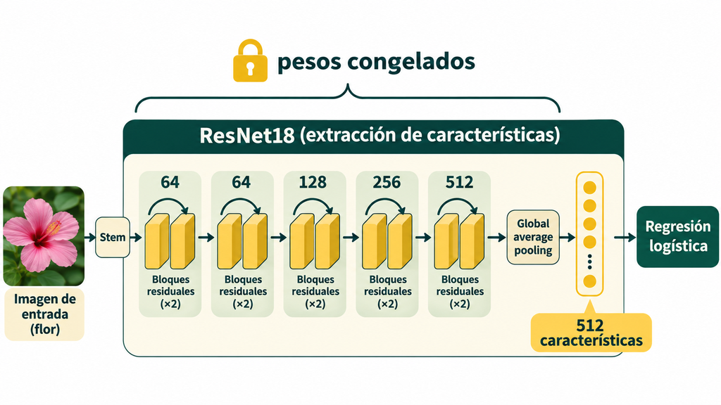

La figura resume el uso de ResNet18 en esta clase. La imagen primero se ajusta al formato esperado por los pesos de ImageNet: tamaño de 224 × 224 píxeles, conversión a tensor y normalización por canal. Después pasa por bloques residuales y una operación de promedio global. Antes de su clasificador original, la red produce una representación de 512 valores.

## 5.1 Ficha técnica de ResNet18

ResNet18 pertenece a la familia de redes residuales presentada por **Kaiming He, Xiangyu Zhang, Shaoqing Ren y Jian Sun**, investigadores de Microsoft Research, en el artículo *Deep Residual Learning for Image Recognition* (2015, publicado en CVPR 2016). El objetivo original no fue clasificar flores ni servir como un extractor genérico. El equipo buscaba resolver el problema de degradación que aparecía al intentar entrenar redes convolucionales cada vez más profundas para reconocimiento visual.

| Aspecto | ResNet18 usada en esta clase |
| --- | --- |
| Profundidad | 18 capas con parámetros aprendibles |
| Tamaño | 11,689,512 parámetros, aproximadamente 11.7 millones |
| Representación previa al clasificador | Vector de 512 componentes |
| Pesos cargados por el notebook | `ResNet18_Weights.DEFAULT`, equivalente a `IMAGENET1K_V1` en TorchVision |
| Datos de preentrenamiento | ImageNet-1K: alrededor de 1.2 millones de imágenes de entrenamiento y 1,000 categorías |
| Tarea original | Clasificación de objetos generales en ImageNet |
| Rendimiento de esos pesos en ImageNet-1K | 69.758 % top-1 y 89.078 % top-5, reportados por TorchVision |

El número de parámetros ayuda a dimensionar el modelo. Son millones de valores numéricos que se ajustaron durante el entrenamiento original. En este notebook se descargan ya aprendidos y se mantienen sin cambios. El vector de 512 características no agrega 512 parámetros entrenables a ResNet18: es simplemente la salida que la red calcula para cada imagen.

ImageNet-1K reúne objetos cotidianos, animales, herramientas, vehículos y escenas de muchas clases. Por eso sus filtros pueden resultar útiles para flores aunque la tarea de origen no sea idéntica a la nuestra. Esta transferencia no garantiza el éxito: si las imágenes de destino tienen iluminación, resolución o contenido muy distinto de ImageNet, la representación puede ser menos adecuada.

**NotaQué significa “18”**

El nombre cuenta las capas con parámetros de la arquitectura, no el número de bloques visibles ni el número de categorías. ResNet18 es una versión relativamente compacta de la familia ResNet. Esto la vuelve apropiada para una clase y para ejecución en CPU, aunque modelos más grandes como ResNet50 tienen mayor capacidad y también mayor costo computacional.

## 5.2 ¿Qué aporta una conexión residual?

En un bloque residual, la red combina una transformación aprendida con una copia de la entrada del bloque. Esta conexión de salto permite que las capas aprendan cambios sobre una representación ya disponible. En redes profundas, esa estructura facilita el flujo de información durante el entrenamiento original.

Para esta clase no necesitamos derivar las ecuaciones de entrenamiento ni modificar los bloques. Basta reconocer dos hechos: ResNet18 ya aprendió sus filtros y nosotros reutilizamos la salida de esos filtros como una nueva tabla de datos.

## 5.3 Del archivo al vector de 512 componentes

```python
weights = ResNet18_Weights.DEFAULT
transform = weights.transforms()
model = resnet18(weights=weights)
model.fc = nn.Identity()       # elimina funcionalmente el clasificador ImageNet
model.eval().to(DEVICE)

with torch.inference_mode():
    vector = model(batch)
```

El resultado tiene una fila por imagen y 512 columnas. No contiene todavía las etiquetas de flores ni una predicción. Por eso podemos usarlo con un clasificador tradicional de scikit-learn.

## 5.4 Otras redes para extracción de características

ResNet18 es una buena primera opción porque su estructura es conocida, sus pesos están disponibles y puede ejecutarse en CPU. No es la única alternativa. La misma estrategia puede aplicarse a otras redes preentrenadas: quitamos o evitamos su clasificador final, congelamos los pesos, extraemos un vector por imagen y entrenamos el mismo clasificador externo.

| Red | Familia e idea central | Tamaño aproximado | Cuándo conviene considerarla |
| --- | --- | --- | --- |
| MobileNetV3-Large | Convoluciones diseñadas para dispositivos con recursos limitados | 5.5 M parámetros, 0.22 GFLOPS | Demostraciones rápidas, CPU o dispositivos móviles |
| EfficientNet-B0 | Escala de manera conjunta profundidad, anchura y resolución | 5.3 M parámetros, 0.39 GFLOPS | Buen punto de comparación cuando se busca eficiencia |
| DenseNet121 | Cada bloque recibe características de capas anteriores | 8.0 M parámetros, 2.83 GFLOPS | Comparar conexiones densas contra conexiones residuales |
| ResNet50 | Variante más profunda de la misma familia residual | 25.6 M parámetros, 4.09 GFLOPS | Más capacidad cuando el tiempo de extracción no es una limitación |
| ConvNeXt-Tiny | CNN moderna inspirada en prácticas recientes de visión | 28.6 M parámetros, 4.46 GFLOPS | Comparar una convolucional moderna con ResNet |
| ViT-B/16 | Transformer visual que procesa parches de imagen | 86.6 M parámetros, 17.56 GFLOPS | Experimentos con GPU y discusión sobre atención visual |

Los parámetros y GFLOPS de la tabla describen configuraciones preentrenadas de TorchVision sobre ImageNet-1K. Sirven para anticipar memoria y tiempo de cómputo, pero no predicen directamente cuál red clasificará mejor las flores. Un modelo con mejor exactitud en ImageNet puede transferirse peor si sus supuestos de preprocesamiento o el dominio visual no coinciden con la nueva tarea.

**TipRecomendación para esta clase**

Después de ResNet18, prueba **EfficientNet-B0**. Es una comparación instructiva porque tiene menos parámetros y menor costo de cómputo, pero sus pesos reportan mayor exactitud en ImageNet-1K. Mantén las mismas particiones 70/15/15, el mismo procedimiento de selección de `C` y la misma regresión logística. Cambia únicamente el extractor y usa siempre `weights.transforms()` de la red elegida.

### 5.4.1 Qué debe cambiar en el código

Cada arquitectura tiene su propio preprocesamiento y su propia capa clasificadora. No conviene reutilizar a ciegas `model.fc = nn.Identity()`, porque ese atributo pertenece a ResNet. La idea general es la misma, pero el punto donde se obtiene el vector depende del modelo.

```python
# Ejemplo conceptual con EfficientNet-B0
from torchvision.models import efficientnet_b0, EfficientNet_B0_Weights

weights = EfficientNet_B0_Weights.DEFAULT
transform = weights.transforms()     # preprocesamiento específico de los pesos
model = efficientnet_b0(weights=weights)
model.classifier = nn.Identity()     # salida de características, no etiquetas ImageNet
model.eval().to(DEVICE)
for parameter in model.parameters():
    parameter.requires_grad = False
```

Guarda las características de cada red en archivos de caché distintos. Si comparas extractores, una sola caché puede mezclar vectores incompatibles y producir conclusiones erróneas.

## 5.5 Tres enfoques para una misma tarea de clasificación

Una misma colección de imágenes de flores puede convertirse en un problema de clasificación de tres maneras. Las tres terminan con una predicción de clase, pero difieren en dónde colocan el conocimiento visual y qué parámetros se ajustan con los datos de la nueva tarea.

| Enfoque | Representación que llega al clasificador | Qué aprende con las flores | Papel del modelo preentrenado |
| --- | --- | --- | --- |
| Descriptores clásicos | Histogramas, GLCM, momentos de color y Hu | Solo la regresión logística | No se usa |
| Extracción profunda | Vector producido por ResNet18 congelada | Solo la regresión logística | Genera características fijas |
| Fine-tuning | Características que cambian durante el entrenamiento | Clasificador final y una parte o toda la red | Se inicializa con pesos preentrenados y luego se ajusta |

### 5.5.1 1. Descriptores clásicos: la persona define qué medir

La ruta clásica transforma cada imagen en medidas explícitas. Elegimos cuántos bins tendrá el histograma, qué distancias y ángulos usar en GLCM, cómo segmentar la región de interés y qué momentos de forma calcular. Después estandarizamos esos valores y ajustamos una regresión logística.

Esta opción es especialmente valiosa cuando sabemos qué propiedad visual distingue las clases y necesitamos explicar una decisión. Por ejemplo, si las clases cambian principalmente en el color, podemos inspeccionar el histograma y entender qué parte del vector influyó en el resultado. Su costo no depende de descargar ni ejecutar una red grande, pero la calidad depende de que nuestros descriptores capturen la variación importante.

### 5.5.2 2. Extracción profunda: la red define una representación fija

Con ResNet18 preentrenada, la imagen pasa por filtros aprendidos en ImageNet y obtenemos un vector de 512 componentes. Los pesos de ResNet18 permanecen congelados. El único modelo que aprende con las flores es la regresión logística situada después de ese vector.

Este enfoque reduce el trabajo de diseñar color, textura y forma por separado. También suele aprovechar patrones visuales más complejos que una sola familia de descriptores. Sin embargo, todavía existe una frontera clara entre conocimiento de origen y tarea de destino: ResNet18 no adapta sus filtros a las flores del curso.

### 5.5.3 3. Fine-tuning: la red adapta parte de sus filtros

Fine-tuning parte de los mismos pesos preentrenados, pero permite que el error de clasificación de flores actualice algunos parámetros. Una práctica habitual consiste en reemplazar el clasificador de ImageNet por una nueva capa con cinco salidas, entrenar primero esa capa y después descongelar los últimos bloques de la red con una tasa de aprendizaje pequeña.

Al ajustar pesos internos, la representación deja de ser fija y puede especializarse en pétalos, fondos, escalas o texturas de la tarea de destino. Esa flexibilidad también introduce riesgos: si hay pocos datos o muchas épocas, la red puede memorizar detalles del entrenamiento y empeorar en imágenes nuevas.

**ImportanteAlcance del notebook actual**

El notebook de esta clase implementa **descriptores clásicos** y **extracción profunda con ResNet18 congelada**. No realiza fine-tuning. Se presenta aquí como una tercera estrategia para comparar conceptos y para una extensión posterior, no como un resultado ya obtenido en el experimento.

### 5.5.4 Comparación práctica

| Criterio | Descriptores clásicos | Extracción profunda | Fine-tuning |
| --- | --- | --- | --- |
| Interpretabilidad de las características | Alta | Media a baja | Media a baja |
| Datos requeridos | Puede funcionar con pocos, si los descriptores son adecuados | Moderados | Usualmente más datos y mayor diversidad |
| Cómputo para entrenar | Bajo | Bajo después de extraer vectores | Mayor, porque calcula gradientes en la red |
| Riesgo principal | Medir algo poco relevante o segmentar mal | Que ImageNet no represente bien el dominio destino | Sobreajuste y selección inadecuada de capas o tasa de aprendizaje |
| Modelo que se ajusta con las flores | Regresión logística | Regresión logística | Clasificador final y capas descongeladas |
| Uso de GPU | No necesaria | Opcional para extraer más rápido | Recomendable |

### 5.5.5 Cómo comparar los tres enfoques con rigor

La comparación debe cambiar una sola decisión a la vez. Conserva las mismas particiones estratificadas 70/15/15 y el mismo conjunto de prueba. Para los dos primeros enfoques, usa la misma búsqueda de `C` de la regresión logística. Para fine-tuning, selecciona en validación la tasa de aprendizaje, el número de bloques descongelados y la época de detención. El conjunto de prueba sigue reservado para una única evaluación final.

No interpretes un mejor resultado de fine-tuning como evidencia automática de que “las redes profundas son mejores”. Puede deberse a más parámetros ajustados, a más tiempo de entrenamiento o a una configuración que consultó demasiadas veces el conjunto de prueba. Reporta siempre cuántas imágenes, épocas, capas desbloqueadas y recursos de cómputo usaste.

### 5.5.6 Regla de decisión inicial

- Elige **descriptores clásicos** cuando la propiedad visual está bien definida, se requiere explicación directa o el conjunto es pequeño y controlado.
- Elige **extracción profunda** como primera línea cuando necesitas una representación sólida sin entrenar una red y quieres una práctica reproducible en CPU o Colab.
- Considera **fine-tuning** cuando la extracción congelada se queda corta, tienes suficientes imágenes diversas y puedes validar cuidadosamente los hiperparámetros de entrenamiento.

# 6 5. Diseño experimental: una comparación justa

La pregunta no es qué ruta tiene más pasos. La pregunta es cuál representación permite separar mejor las mismas categorías bajo las mismas condiciones.

## 6.1 Particiones compartidas

El notebook crea particiones estratificadas con semilla fija:

| Conjunto | Proporción | Propósito |
| --- | --- | --- |
| Entrenamiento | 70 % | Ajustar parámetros de la regresión logística |
| Validación | 15 % | Elegir el valor de `C` sin consultar prueba |
| Prueba | 15 % | Estimar desempeño final una vez |

La estratificación conserva aproximadamente la proporción de cada flor en los tres conjuntos. Las dos rutas leen exactamente las mismas listas de archivos.

## 6.2 Qué se entrena en cada ruta

1. Extraemos la matriz clásica o profunda para entrenamiento, validación y prueba.
2. Ajustamos `StandardScaler` con las características de entrenamiento.
3. Probamos valores candidatos de `C` y seleccionamos el mejor con F1 macro en validación.
4. Reajustamos la regresión logística con entrenamiento más validación.
5. Evaluamos una sola vez sobre prueba.

**PrecauciónEvitar fuga de información**

El escalador no debe calcular media ni desviación estándar con imágenes de prueba. Tampoco debemos elegir `C` usando la exactitud de prueba. Cualquiera de esas decisiones haría que la estimación final pareciera mejor de lo que será en datos nuevos.

# 7 6. Lectura de resultados

El notebook genera resultados reales cada vez que se ejecuta. No incorpora números de ejemplo en esta lección porque el modo `DEMO`, la versión de las bibliotecas y las imágenes procesadas pueden cambiar los valores.

## 7.1 Métricas

- **Exactitud:** proporción total de predicciones correctas. Puede ocultar clases difíciles si las categorías tienen tamaños distintos.
- **Precisión macro:** promedio de la precisión por clase. Penaliza las predicciones de una clase que en realidad pertenecen a otra.
- **Sensibilidad macro:** promedio de los ejemplos de cada clase que el modelo recupera correctamente.
- **F1 macro:** equilibrio entre precisión y sensibilidad, calculado para cada clase y promediado sin ponderar por su tamaño.

## 7.2 Matriz de confusión

La matriz muestra etiqueta real en las filas y predicción en las columnas. La diagonal representa aciertos. Una celda fuera de la diagonal responde a una pregunta útil: ¿qué dos categorías confunde el modelo?

Cuando examines la matriz, no concluyas solamente “ResNet18 ganó” o “los descriptores clásicos ganaron”. Busca una explicación visual para cada confusión frecuente: pétalos similares, fondo dominante, flor muy pequeña o una fotografía con más de un objeto.

## 7.3 PCA como exploración

PCA reduce el vector a dos ejes que explican la mayor varianza posible. Es una herramienta para explorar si las categorías tienden a agruparse, pero no sustituye la evaluación del clasificador.

Si los puntos de dos categorías se mezclan en PCA, eso no demuestra que sean inseparables en 512 dimensiones. Si aparecen separados, tampoco garantiza que el clasificador generalice. La gráfica debe acompañarse con su varianza explicada y con las métricas de prueba.

# 8 7. Actividad de cierre

1. Ejecuta el notebook con `DEMO = True` y compara la tabla de métricas.
2. Identifica una confusión recurrente en cada matriz.
3. Abre algunas imágenes mal clasificadas. Formula una causa visual plausible antes de cambiar código.
4. Propón un cambio para la ruta clásica y explica qué limitación intenta corregir.
5. Discute si el beneficio de fine-tuning justificaría su costo para este conjunto de datos.

## 8.1 Idea final

Los dos enfoques producen vectores y ambos necesitan una evaluación rigurosa. Los descriptores clásicos expresan decisiones explícitas sobre qué medir. El aprendizaje por transferencia reutiliza decisiones que un modelo tomó al aprender de una gran colección de imágenes. Elegir entre ellos depende del problema, de la cantidad de datos, de la necesidad de interpretación y del comportamiento real del sistema sobre imágenes nuevas.

# 9 Referencias

- He, K., Zhang, X., Ren, S. y Sun, J. (2016). *Deep Residual Learning for Image Recognition*. CVPR. https://doi.org/10.1109/CVPR.2016.90.
- PyTorch / TorchVision. *ResNet18 weights and transforms*. https://pytorch.org/vision/stable/models/resnet.html.
- PyTorch / TorchVision. *ResNet18 weights: parameters, transforms and ImageNet-1K performance*. https://docs.pytorch.org/vision/stable/models/generated/torchvision.models.resnet18.html.
- PyTorch / TorchVision. *Models and pre-trained weights*. https://docs.pytorch.org/vision/stable/models.html.
- TensorFlow. *Flower Photos dataset*. https://storage.googleapis.com/download.tensorflow.org/example_images/flower_photos.tgz.
- Haralick, R. M., Shanmugam, K. y Dinstein, I. (1973). *Textural Features for Image Classification*. IEEE Transactions on Systems, Man, and Cybernetics, 3(6), 610–621.
- Hu, M.-K. (1962). *Visual Pattern Recognition by Moment Invariants*. IRE Transactions on Information Theory, 8(2), 179–187.